# Increases in California Mortaily in 2020 - Exploration

# After many years of decreasing or level death rates in California the rate increased substantailly in 2020

- Most of this increase is due directly to Covid-19
- Some of the increase is due to other conditions

## All-Cause Death Rate by Quarter and Year, California 2017-2020

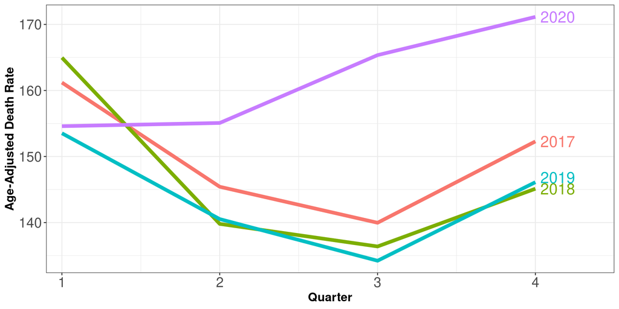

## All Cause Age-Adjusted Mortality Rate by Race/Ethnicity and YearGroup, California 2017-2020",

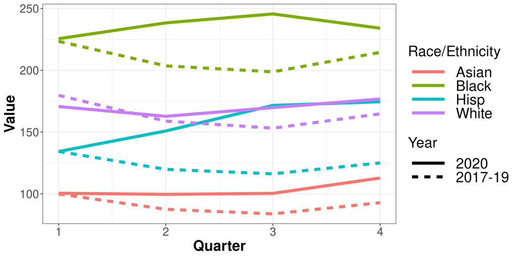

# Data/Methods

- California vital statistic death data received mid-January 2021
  - number of 2020 deaths are not quite complete
  - cause of death coding is not complete – particularly for Quarter 3 (Q3) and Quarter 4 (Q4) (Q4 is too incomplete to include in this analysis)
- Compare 2019 and 2020 Q2 and Q3 cause-specific age-adjusted deaths rates and numbers of deaths
- Analysis restricted to conditions with at least 500 deaths in Q3 or Q4 2020
- Cause of death condition groupings and age-adjustment calculations use the [California Community Burden of Disease Engine](https://skylab.dev.cdph.ca.gov/communityBurden/) tools and data systems

# Key Summary Observations

- Aside from COVID-19, the conditions with the five **largest percentage increases** from 2019 to 2020 were
  - Drug overdose/poisonings (45% Q2 increase, 37% Q3)
  - Homicide (38% Q3 increase)
  - Diabetes (29% Q3 increase)
  - Endocrine, blood, and immune disorders (23% increase)
- The conditions with the five **largest absolute increases** from 2019 to 2020 were
  - Alzheimer’s disease (N=1267 increase Q3, N=757 increase Q2)
  - Ischemic heart disease (1060), reversing a steady prior decreases
  - Drug overdose/poisoning (N=594 increase Q2, N=536 Q3)
- Regarding **decreases**
  - suicide has the largest percentage and absolute decrease of any condition in both Q2 and Q3
  - lung cancer had large percentage and absolute decreases in both Q2 and Q3

| quarter | causeName | Ndeaths_2017 | Ndeaths_2018 | Ndeaths_2019 | Ndeaths_2020 | aRate_2017 | aRate_2018 | aRate_2019 | aRate_2020 | percent_change19_20 | numchange19_20 |
| --- | --- | --- | --- | --- | --- | --- | --- | --- | --- | --- | --- |
| 2 | Drug poisonings | 1,104 | 1,139 | 1,359 | 1,953 | 2.7 | 2.8 | 3.3 | 4.8 | 45.0% | 594 |
| 3 | Homicide/Interpersonal violence | 501 | 532 | 466 | 632 | 1.3 | 1.3 | 1.2 | 1.6 | 37.5% | 166 |
| 3 | Drug poisonings | 1,109 | 1,276 | 1,444 | 1,980 | 2.7 | 3.1 | 3.5 | 4.9 | 37.4% | 536 |
| 3 | Diabetes mellitus | 1,312 | 1,355 | 1,311 | 1,732 | 3.0 | 3.0 | 2.8 | 3.6 | 28.5% | 421 |
| 1 | Drug poisonings | 956 | 1,174 | 1,271 | 1,624 | 2.3 | 2.8 | 3.1 | 3.9 | 28.2% | 353 |
| 3 | Endocrine, blood, immune disorders | 897 | 842 | 870 | 1,085 | 2.0 | 1.9 | 1.9 | 2.3 | 23.2% | 215 |
| 2 | Homicide/Interpersonal violence | 531 | 497 | 469 | 572 | 1.4 | 1.3 | 1.2 | 1.4 | 21.8% | 103 |
| 3 | Alzheimer’s disease and other dementias | 5,644 | 5,594 | 5,895 | 7,162 | 12.3 | 11.9 | 12.1 | 14.3 | 17.9% | 1,267 |
| 2 | Diabetes mellitus | 1,362 | 1,352 | 1,473 | 1,751 | 3.1 | 3.0 | 3.2 | 3.7 | 15.6% | 278 |
| 3 | Ischemic heart disease | 8,406 | 8,414 | 8,186 | 9,246 | 18.6 | 18.1 | 17.2 | 18.9 | 10.0% | 1,060 |
| 2 | Endocrine, blood, immune disorders | 812 | 905 | 931 | 1,051 | 1.9 | 2.0 | 2.1 | 2.3 | 9.7% | 120 |
| 2 | Alzheimer’s disease and other dementias | 5,975 | 5,791 | 6,177 | 6,934 | 13.0 | 12.2 | 12.7 | 13.9 | 9.3% | 757 |
| 1 | Alzheimer’s disease and other dementias | 6,852 | 7,338 | 6,783 | 7,199 | 14.9 | 15.5 | 13.9 | 14.4 | 3.1% | 416 |
| 2 | Ischemic heart disease | 9,071 | 8,906 | 8,819 | 9,267 | 20.0 | 19.2 | 18.5 | 19.0 | 2.5% | 448 |
| 1 | Endocrine, blood, immune disorders | 982 | 1,063 | 1,033 | 1,042 | 2.2 | 2.4 | 2.2 | 2.2 | −0.9% | 9 |
| 1 | Suicide/Self-harm | 1,017 | 1,059 | 1,063 | 1,040 | 2.5 | 2.6 | 2.5 | 2.5 | −2.3% | −23 |
| 1 | Diabetes mellitus | 1,717 | 1,748 | 1,712 | 1,719 | 3.9 | 3.8 | 3.7 | 3.6 | −3.2% | 7 |
| 1 | Ischemic heart disease | 10,760 | 10,661 | 10,027 | 9,936 | 23.8 | 22.9 | 21.0 | 20.3 | −3.3% | −91 |
| 1 | Trachea, bronchus and lung cancers | 2,873 | 2,868 | 2,779 | 2,726 | 6.5 | 6.4 | 5.9 | 5.7 | −4.6% | −53 |
| 3 | Trachea, bronchus and lung cancers | 2,888 | 2,699 | 2,657 | 2,510 | 6.5 | 5.9 | 5.7 | 5.2 | −8.4% | −147 |
| 2 | Trachea, bronchus and lung cancers | 2,877 | 2,634 | 2,640 | 2,474 | 6.5 | 5.8 | 5.7 | 5.1 | −9.4% | −166 |
| 3 | Suicide/Self-harm | 1,101 | 1,174 | 1,177 | 1,011 | 2.7 | 2.8 | 2.8 | 2.4 | −15.3% | −166 |
| 2 | Suicide/Self-harm | 1,095 | 1,106 | 1,119 | 931 | 2.7 | 2.7 | 2.7 | 2.2 | −16.3% | −188 |

# Exploratory Trend Charts

## Quarterly Trend in Selected Causes 2017-2020

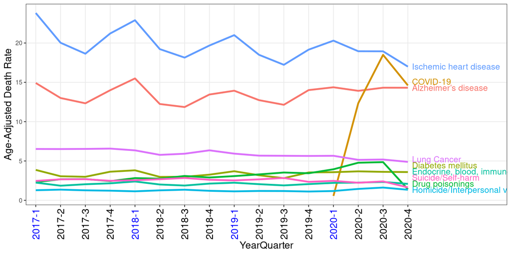

## Quarterly Trend in Selected Causes 2017-2020, with adjustment for missing data

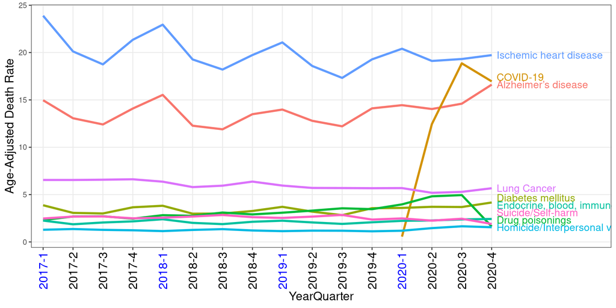

## Quarterly Trend in Selected Causes 2017-2020, with adjustment for missing data, exclude Q4 2020

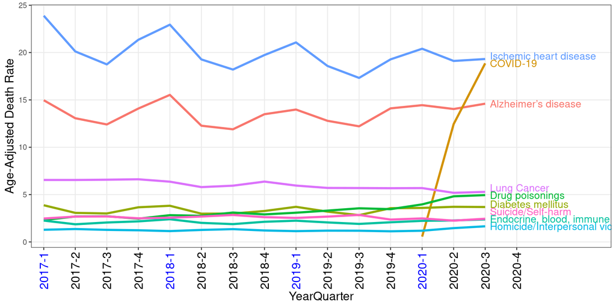

## Quarterly Trend in Selected Causes 2017-2020, with adjustment for missing data, exclude Q4 2020, y-axis log scale

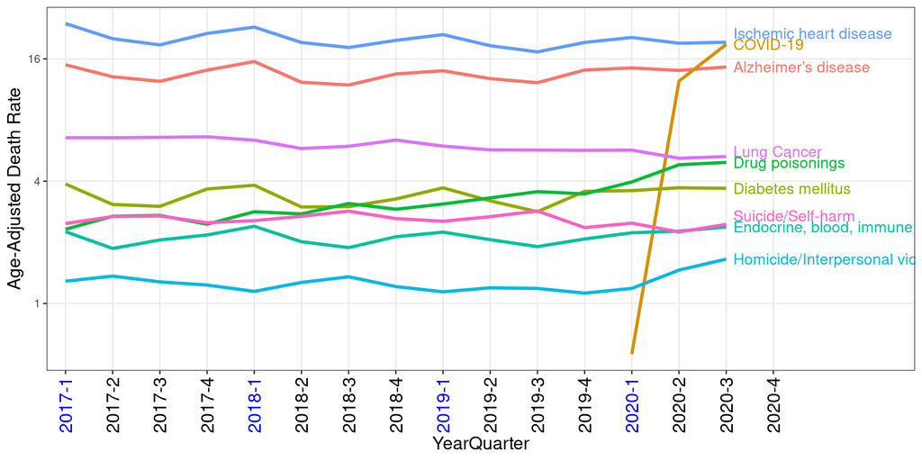

# Next Steps

- Tidy up this document
- Obtain updated 2020 data
- Determine who can use these findings, and expanded analyses, for what purposes
- Determine who else at CDPH, CHHS and academic partners are doing related analyses, and collaborate with these entities
- Provide additional analyses and data